# Lecture 3-1: Flow Control

# Agenda

- Conditionals: switching between different calculations.
- Iteration: Doing something over and over.
- Vectorizing: Avoiding explicit iteration.

# Conditionals

Have the computer decide what to do next.

Example 1:

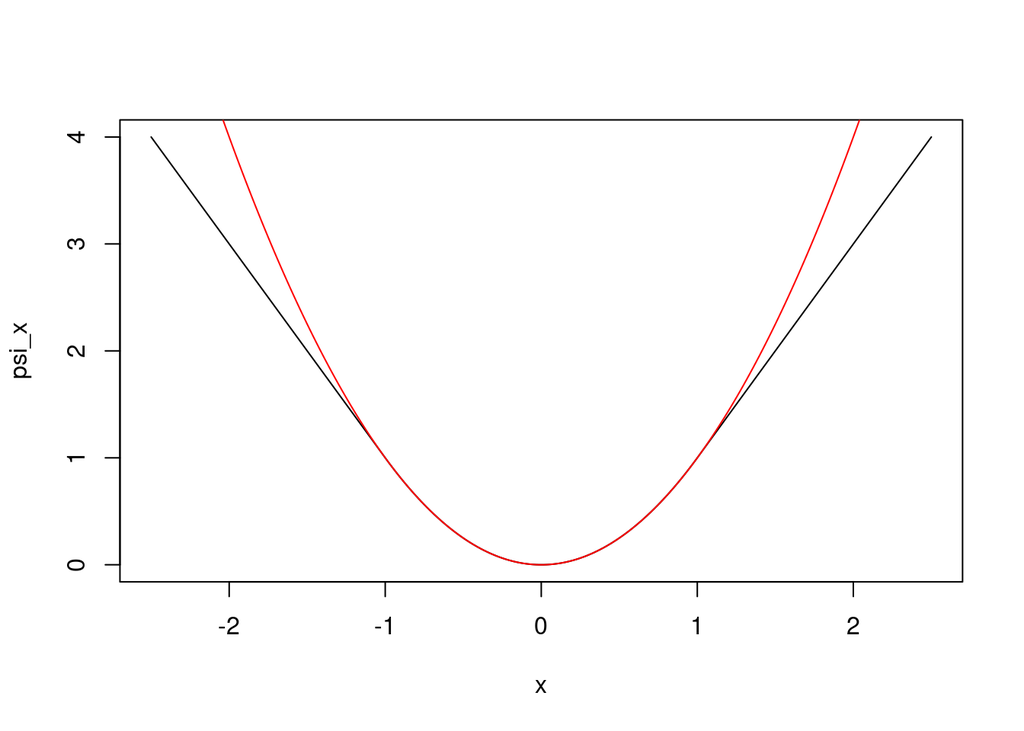

```r
x <- seq(-2.5, 2.5, 0.01)
psi_x <- numeric(length(x))
psi_x[x < -1] <- 2 * abs(x[x < -1]) - 1
psi_x[x >= -1 & x <= 1] <- (x[x >= -1 & x <= 1]) ^ 2
psi_x[x > 1] <- 2 * abs(x[x > 1]) - 1

plot(x, psi_x, type = "l")
lines(x, x^2, col = "red")
```

Example 2: if the country code is not `"US"`, multiply prices by current exchange rate.

# if( )

Simplest conditional:

```r
if (condition) {
  do_something
}
```

For example:

```r
love = FALSE
if (love == TRUE) {
  print("Yes!")
}
```

Slightly less simple conditional:

```r
if (condition) {
 do_something
} else {
 do_something_else
}
```

For example, compute the absolute value:

```r
x <- -5
if (x >= 0) {
  abs_x <- x
} else {
  abs_x <- -x
}
abs_x
```

```
## [1] 5
```

Try the above with a vector, say c(-5, 3, -2, 1, 0), does it work? No! the condition has to be TRUE / FALSE of length 1. The exception is that a numeric value of length 1 is recast as FALSE if 0, TRUE if anything else.

To convince yourself about the above statement, examine the below conditions:

```r
if (1) { print("Got here") }
if (0) { print("Got here") }
if (NA) { print("Got here") }
if (NaN) { print("Got here") }
if (-Inf) { print("Got here") }
(0.5 - 0.3) - (0.3 - 0.1)
if ((0.5 - 0.3) - (0.3 - 0.1)) { print("Got here") }
if (!all.equal((0.5 - 0.3) - (0.3 - 0.1), 0)) { print("Got here") }
```

Note, one-line actions don’t need curly braces (you will see this when you read code, not recommended):

```r
if (x >= 0) x else -x
```

```
## [1] 5
```

# Nested if( )

`if` can *nest* arbitrarily deeply:

```r
if (x^2 < 1) {
  x^2
} else {
  if (x >= 0) {
    2*x-1
  } else {
     -2*x-1
  }
}
```

```
## [1] 9
```

# Combining logicals: && and ||

`&` and `|` work like `+` or `*`, combining terms element-wise while `&&` and `||` evaluate left to right examining only the first element of each vector.

Evaluation proceeds only until the result is determined.

```r
c(1, 2, 3) < 2.5
```

```
## [1]  TRUE  TRUE FALSE
```

```r
(0 == 0) & (c(1, 2, 3) < 1.5)
```

```
## [1]  TRUE FALSE FALSE
```

```r
(0 == 0) && (c(1, 2, 3) < 1.5)
```

```
## [1] TRUE
```

```r
(0 > 0) & (print("5") != "5")
```

```
## [1] "5"
```

```
## [1] FALSE
```

```r
(0 > 0) && c(print("5") != "5", print("6") != "5")
```

```
## [1] FALSE
```

```r
(0 == 0) && c(print("5") != "5", print("6") != "5")
```

```
## [1] "5"
## [1] "6"
```

```
## [1] FALSE
```

```r
(0 == 0) | (print("5") != "5")
```

```
## [1] "5"
```

```
## [1] TRUE
```

```r
(0 > 0) || c((print("5") != "5"), (print("6") != "5"))
```

```
## [1] "5"
## [1] "6"
```

```
## [1] FALSE
```

```r
(0 == 0) || c((print("5") != "5"), (print("6") != "5"))
```

```
## [1] TRUE
```

# switch( )

The `switch()` function tests an expression against elements of a `list`. Simplify nested `if` with `switch()`: give a variable to select on, then a value for each option:

```r
EXPR <- 2
switch(EXPR,
       "red",
       "green",
       "blue"
       )
```

```
## [1] "green"
```

```r
switch(EXPR + 1,
       "red",
       "green",
       "blue"
       )
```

```
## [1] "blue"
```

```r
EXPR <- "color"
switch(EXPR,
       color = "red",
       shape = "square",
       length = 5
       )
```

```
## [1] "red"
```

```r
EXPR <- "length"
switch(EXPR,
       color = "red",
       shape = "square",
       length = 5
       )
```

```
## [1] 5
```

Another example:

```r
library(datasets)
states <-
  data.frame(
    state.x77,
    abb = state.abb,
    region = state.region,
    division = state.division
    )
type.of.summary <- "median"
switch(
  type.of.summary,
  mean = mean(states$Murder),
  median = median(states$Murder),
  histogram = hist(states$Murder),
  "What?!")
```

```
## [1] 6.85
```

```r
type.of.summary <- "something"
switch(
  type.of.summary,
  mean = mean(states$Murder),
  median = median(states$Murder),
  histogram = hist(states$Murder),
  "What?!"
  )
```

```
## [1] "What?!"
```

# Iteration Three ways

- `for(){}`
- `while(){}`
- `repeat{}`: `repeat` has no Boolean exit condition. You must use break.

# for( )

```r
vector_of_logarithms <- numeric(7)
vector_of_indices <- 1:7
for (i in vector_of_indices) {
  cat(paste0("i = ", i, "\n"))
  vector_of_logarithms[i] <- log(i)
}
```

```
## i = 1
## i = 2
## i = 3
## i = 4
## i = 5
## i = 6
## i = 7
```

```r
vector_of_logarithms
```

```
## [1] 0.0000000 0.6931472 1.0986123 1.3862944 1.6094379 1.7917595 1.9459101
```

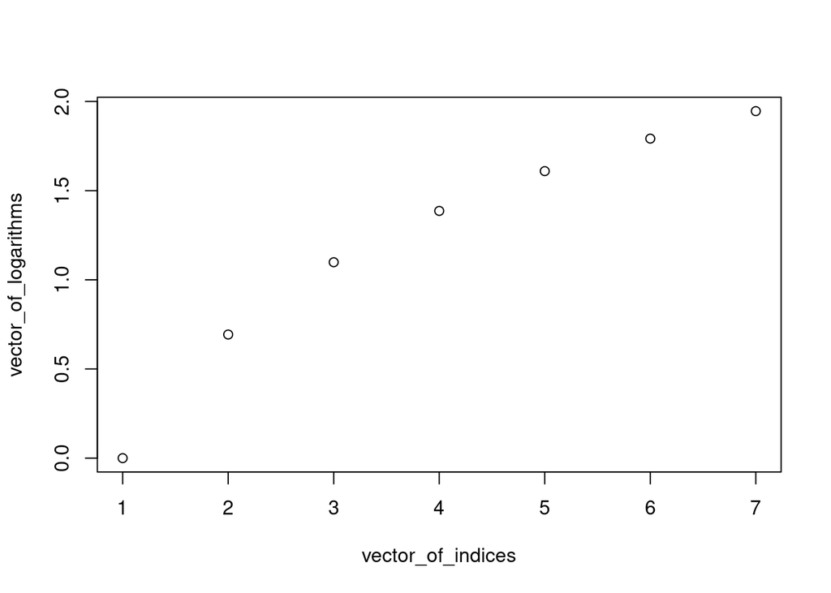

```r
plot(vector_of_indices, vector_of_logarithms)
```

Of course, it is most commonly used as:

```r
another_vector_of_logarithms <- numeric(7)
for (i in 1:7) {
  cat(paste0("i = ", i, "\n"))
  another_vector_of_logarithms[i] <- log(i)
}
```

```
## i = 1
## i = 2
## i = 3
## i = 4
## i = 5
## i = 6
## i = 7
```

`for` construct works on any vector. You can loop over a vector of names (or file names), for instance.

```r
smurf_names <-
  c("Smurfette",
    "Papa Smurf",
    "Clumsy Smurf",
    "Brainy Smurf",
    "Grouchy Smurf",
    "Hefty Smurf"
    )

for (smurf_name in smurf_names) {
  if (rbinom(1, 1, 0.5)) {
    cat(paste0("I love you ", smurf_name, "!\n"))
  } else {
    cat(paste0("I love you not, ", smurf_name, "!\n"))
  }
}
```

```
## I love you Smurfette!
## I love you not, Papa Smurf!
## I love you Clumsy Smurf!
## I love you Brainy Smurf!
## I love you Grouchy Smurf!
## I love you not, Hefty Smurf!
```

Or you can loop over a list (= non-atomic vector)

```r
list_to_iterate_over <- list(1, "character", FALSE)
for (l in list_to_iterate_over) {
  print(typeof(l))
}
```

```
## [1] "double"
## [1] "character"
## [1] "logical"
```

# Nested Iteration Example

```r
A = matrix(1:10, nrow = 2, ncol = 5)
B = matrix(11:25, nrow = 5, ncol = 3)
C <- matrix(0, nrow = nrow(A), ncol = ncol(B))
if (ncol(A) == nrow(B)) {
  for (i in 1:nrow(C)) {
    for (j in 1:ncol(C)) {
      for (k in 1:ncol(A)) {
        C[i,j] <- C[i,j] + A[i,k] * B[k,j]
      }
    }
  }
} else {
  stop("matrices a and b non-conformable")
}
```

Compare to:

```r
A %*% B == C
```

```
##      [,1] [,2] [,3]
## [1,] TRUE TRUE TRUE
## [2,] TRUE TRUE TRUE
```

`next` statement skips the remainder of the current iteration of the loop and proceed directly to the next one, `break` statement exists the loop.

```r
x <- 1:6
for (val in x) {
  if (val == 3){
    next
  }
  if (val == 6) {
    break
  }
  print(val)
}
```

```
## [1] 1
## [1] 2
## [1] 4
## [1] 5
```

# while( ): Conditional Iteration

Take the square root of `x0` until it is close enough to 1:

```r
x0 <- 7
x <- x0
{
  i <- 1
  cat(paste0("x = ", x, "\n"))
  while (x - 1 > 1e-06) {
    x <- sqrt(x)
    cat(paste0(x0, "^(1/", 2 ^ i,  ") = ", x, "\n"))
    i = i + 1
  }
}
```

```
## x = 7
## 7^(1/2) = 2.64575131106459
## 7^(1/4) = 1.62657656169779
## 7^(1/8) = 1.27537310685845
## 7^(1/16) = 1.12932418147247
## 7^(1/32) = 1.06269665543487
## 7^(1/64) = 1.03087179388849
## 7^(1/128) = 1.01531856768627
## 7^(1/256) = 1.007630174065
## 7^(1/512) = 1.00380783722035
## 7^(1/1024) = 1.00190210959971
## 7^(1/2048) = 1.00095060297685
## 7^(1/4096) = 1.00047518858633
## 7^(1/8192) = 1.00023756607434
## 7^(1/16384) = 1.0001187759833
## 7^(1/32768) = 1.00005938622829
## 7^(1/65536) = 1.00002969267332
## 7^(1/131072) = 1.00001484622645
## 7^(1/262144) = 1.00000742308568
## 7^(1/524288) = 1.00000371153595
## 7^(1/1048576) = 1.00000185576625
## 7^(1/2097152) = 1.0000009278827
```

The condition in the argument to `while()` must be a single logical value (like `if()`). The body is looped over until the condition is `FALSE`. The loop never begins unless the condition starts `TRUE`.

# for( ) vs. while( )

`for()` is better when the number of times to repeat (values to iterate over) is clear in advance, while `while()` is better when you can recognize when to stop once you’re there, even if you can’t guess it to begin with. Every `for()` could be replaced with a `while()`.

# repeat

```r
# We use the `eval = FALSE` in the header of this code chunk.
# This shows the code, but doesn't run it. The following `repeat` command
# will be an infinite loop, as there is no `break` command:
repeat {}
```

Sample from the normal distribution and stop when an observation is larger in absolute value than 2.5:

```r
repeat {
  s <- rnorm(1)
  cat(paste0(round(s, 3), "; "))
  if (abs(s) > 2.5) {
    break
  }
}
```

```
## -0.881; 2.596;
```

## Vectorization

As we have seen, many very basic operations in R actually involve a whole set of operations that run in the background. This may potentially cause R code to be slow, compared to compiled (C, C++, Java) code. Many operations can be *vectorized*. That is, some of the operations skipped, memory allocated in a more efficient fashion, and loops carried out in C or C++. This, at times, can significantly accelerate your code.

For a nice introduction to vectorization in R, see: https://www.r-bloggers.com/vectorization-in-r-why/

# Example 1:

```r
N <- 10
a <- rnorm(N)
b <- rnorm(N)

# An awful way to compute the sum of the vectors `a` and `b`:
a_plus_b_ver1 <- a[1] + b[1]
for (i in 2:N) {
  a_plus_b_ver1[i] <- a[i] + b[i]
}

# A slightly less awful way to compute the sum of two vectors:
a_plus_b_ver2 <- numeric(N)
for (i in 1:N) {
  a_plus_b_ver2[i] <- a[i] + b[i]
}

# We "vectorized" the memory allocation.

# A good way to copmute the sum of two vectors:
a_plus_b_ver3 <- a + b

# The `+` operator vectorizes both memory allocation and element-by-element addition.
# The addition is done in C.
```

Let’s measure the relative speed using the `microbenchmark` function from the `microbenchmark` package:

```r
N <- 100000
a <- rnorm(N)
b <- rnorm(N)

res <-
  microbenchmark::microbenchmark(
    {
      a_plus_b_ver1 <- a[1] + b[1]
      for (i in 2:N) {
        a_plus_b_ver1[i] <- a[i] + b[i]
      }
    },
    {
      a_plus_b_ver2 <- numeric(N)
      for (i in 1:N) {
        a_plus_b_ver2[i] <- a[i] + b[i]
      }
    },
    {
      a_plus_b_ver3 <- a + b
    },
    unit = "ns" # for "nanoseconds"
  )
sum_res <- summary(res)
sum_res
```

```
##                                                                                                      expr
## 1 {     a_plus_b_ver1 <- a[1] + b[1]     for (i in 2:N) {         a_plus_b_ver1[i] <- a[i] + b[i]     } }
## 2  {     a_plus_b_ver2 <- numeric(N)     for (i in 1:N) {         a_plus_b_ver2[i] <- a[i] + b[i]     } }
## 3                                                                          {     a_plus_b_ver3 <- a + b }
##        min         lq       mean     median       uq      max neval cld
## 1 25607469 27487779.5 29148572.8 29141251.0 30190272 34753163   100   c
## 2  9898324 10619301.0 11230378.7 11007426.5 11614699 14518286   100  b
## 3    68676   128576.5   171682.5   140012.5   201205   578316   100 a
```

```r
sum_res$median[1] / sum_res$median[2]
```

```
## [1] 2.647417
```

```r
sum_res$median[2] / sum_res$median[3]
```

```
## [1] 78.61746
```

Using the triple `for()` loop we wrote earlier vs. `a %*% b` will be even worse…

# Vectorized Calculations

Many functions are set up to vectorize automatically, by avoiding superfluous checks and executing code in C:

```r
abs(-3:3)
```

```
## [1] 3 2 1 0 1 2 3
```

```r
log(1:7)
```

```
## [1] 0.0000000 0.6931472 1.0986123 1.3862944 1.6094379 1.7917595 1.9459101
```

We saw the `apply()` family in the previous lecture.

# Vectorized Conditions

The `ifelse` function: 1st argument is a logical vector, then pick from the 2nd or 3rd arguments, first for `TRUE` and then for `FALSE`.

```r
N <- 10000
x <- runif(N, -5, 5)
y1 <-
  ifelse(
    x^2 < 1,
    x^2,
    ifelse(
      x >= 0,
      2 * x - 1,
      -2 * x - 1
    )
  )
```

Compare to:

```r
y2 <- numeric(N)
for (i in 1:N) {
  if (x[i]^2 < 1) {
    y2[i] <- x[i]^2
  } else {
    if (x[i] >= 0) {
      y2[i] <- 2 * x[i] - 1
    } else {
      y2[i] <- -2 * x[i] - 1
    }
  }
}

# Sanity check:
all(y1 == y2)
```

```
## [1] TRUE
```

Speed:

```r
N <- 10000
x <- runif(N, -5, 5)
res <-
  microbenchmark::microbenchmark(
    {
      y1 <-
        ifelse(
          x^2 < 1,
          x^2,
          ifelse(
            x >= 0,
            2 * x - 1,
            -2 * x - 1
          )
        )
    },
    {
      y2 <- numeric(N)
      for (i in 1:N) {
        if (x[i]^2 < 1) {
          y2[i] <- x[i]^2
        } else {
          if (x[i] >= 0) {
            y2[i] <- 2 * x[i] - 1
          } else {
            y2[i] <- -2 * x[i] - 1
          }
        }
      }
    }
  )
sum_res <- summary(res)
sum_res$median[2] / sum_res$median[1]
```

```
## [1] 16.03498
```

It is important to notice that the performance may also depend on the input values. What do you expect will happen if we repeat the same computation with x <- runif(N, another_lower_boundary, another_upper_boundary)?

# Summary

- `if`, nested `if`, `switch`.
- Iteration: `for`, `while`, `repeat`.
- Avoiding iteration with whole-object (“vectorized”) operations.